# Finding region of steepest slope

John Flournoy

2020-07-07

```r
library(mgcv)
library(gratia)
library(boot)
library(dplyr)
library(ggplot2)
```

Loading and preparing data, including fitting GAM models with smooth terms using both maximum-likelihood and Bayesian methods.

```r
hcpd_data <- readr::read_csv("hcpd_n762_myelin_cog_data.csv")
eps = 1e-07
res = 50

right_side <- '~ s(Age) + Sex + Scanner + numNavs_sum'
left_side <- 'mean_wholebrain_T1wT2w'

mf_form <- as.formula(paste0(left_side, gsub('s\\((.*)\\)', '\\1', right_side)))
form <- as.formula(paste0(left_side, right_side))

d <- model.frame(formula = mf_form, data = hcpd_data)
agerange <- range(d$Age)
```

```r
cat(sprintf('Setting resolution for derivative across ages %.0f-%.0f to %d increments of %.1f years each.', agerange[[1]], agerange[[2]], res, diff(agerange)/res))
```

Setting resolution for derivative across ages 8-22 to 50 increments of 0.3 years each.

```r
fit <- mgcv::gam(form, data=d, method="REML")
deriv1 <- gratia::derivatives(fit, n = res, eps = eps, level = .95, interval = 'simultaneous', unconditional = TRUE, n_sim = 10000)
deriv1aa <- gratia::derivatives(fit, n = res, eps = eps, level = .95, interval = 'simultaneous', unconditional = FALSE, n_sim = 10000)
deriv1a <- gratia::derivatives(fit, n = res, eps = eps, level = .95, interval = 'confidence', unconditional = TRUE)
deriv1b <- gratia::derivatives(fit, n = res, eps = eps, level = .95, interval = 'confidence', unconditional = FALSE)

library(brms)
library(data.table)

fit_brm <- brms::brm(brms::bf(form),
                     data=d,
                     chains = 4, cores = 4,
                     iter = 4500, warmup = 2000,
                     control = list(adapt_delta = .999, max_treedepth = 20),
                     file = 'fit_brm')


source('conditional_smooth_sample.R')
c_smooths_1 <- conditional_smooth_sample(fit_brm, smooths = 's(Age)',
                                         smooth_values = list('Age' = seq(min(d$Age), max(d$Age), length.out = res)),
                                         probs = c(0.025, 0.975),
                                         spaghetti = TRUE)
c_smooths_2 <- conditional_smooth_sample(fit_brm, smooths = 's(Age)',
                                         smooth_values = list('Age' = seq(min(d$Age), max(d$Age), length.out = res) + eps),
                                         probs = c(0.025, 0.975),
                                         spaghetti = TRUE)

c_smooths_1_sample_data <- data.table(attr(c_smooths_1$`mu: s(Age)`, 'spaghetti'))
c_smooths_2_sample_data <- data.table(attr(c_smooths_2$`mu: s(Age)`, 'spaghetti'))

c_smooths_1_sample_data[, estimate__eps := c_smooths_2_sample_data[,estimate__]]
c_smooths_1_sample_data[, deriv1 := (estimate__eps - estimate__) / eps]

smooth_post_summary <- c_smooths_1_sample_data[, list(est = median(estimate__),
                                                      'lower' = quantile(estimate__, probs = .025),
                                                      'upper' = quantile(estimate__, probs = .975)),
                                               by = 'Age']

deriv1_post_summary <- c_smooths_1_sample_data[, list('deriv1' = median(deriv1),
                                                      'lower' = quantile(deriv1, probs = .025),
                                                      'upper' = quantile(deriv1, probs = .975)),
                                               by = 'Age']

deriv1_age_at_max_post <- c_smooths_1_sample_data[, list('max_age' = Age[which(deriv1 == max(deriv1))]),
                                                  by = 'sample__']
age_at_max_med_deriv <- deriv1_post_summary[deriv1 == max(deriv1), Age]
deriv1_diff_from_max_post <- c_smooths_1_sample_data[, diff_from_max := deriv1 - deriv1[Age == age_at_max_med_deriv],
                                                     by = 'sample__']
deriv1_diff_from_max_post_summary <- deriv1_diff_from_max_post[, list('diff_from_max' = median(diff_from_max),
                                                                      'lower' = quantile(diff_from_max, probs = .025),
                                                                      'upper' = quantile(diff_from_max, probs = .975)),
                                                               by = 'Age']
deriv1_diff_from_max_post_summary[, compared_to_max := case_when(upper < 0 ~ 'less_steep',
                                                                 lower > 0 ~ 'steeper',
                                                                 TRUE ~ 'as_steep')]

deriv1_post_summary <- deriv1_post_summary[deriv1_diff_from_max_post_summary[, .(Age, compared_to_max)], on = 'Age']
```

# Summary of ML and Bayesian fits

## ML

```r
summary(fit)
```

```
##
## Family: gaussian
## Link function: identity
##
## Formula:
## mean_wholebrain_T1wT2w ~ s(Age) + Sex + Scanner + numNavs_sum
##
## Parametric coefficients:
##                   Estimate Std. Error t value Pr(>|t|)
## (Intercept)      1.3010559  0.0387735  33.555  < 2e-16 ***
## SexM             0.0131926  0.0047953   2.751  0.00608 **
## ScannerUCLA-BMC -0.0027984  0.0085534  -0.327  0.74363
## ScannerUCLA-CCN -0.0143693  0.0091923  -1.563  0.11843
## ScannerUMN       0.0095648  0.0061942   1.544  0.12297
## ScannerWU-Bay2  -0.0028204  0.0065922  -0.428  0.66889
## ScannerWU-Bay3   0.0322113  0.0210042   1.534  0.12556
## numNavs_sum      0.0009938  0.0001348   7.374  4.4e-13 ***
## ---
## Signif. codes:  0 '***' 0.001 '**' 0.01 '*' 0.05 '.' 0.1 ' ' 1
##
## Approximate significance of smooth terms:
##        edf Ref.df     F p-value
## s(Age) 3.4  4.224 190.9  <2e-16 ***
## ---
## Signif. codes:  0 '***' 0.001 '**' 0.01 '*' 0.05 '.' 0.1 ' ' 1
##
## R-sq.(adj) =  0.525   Deviance explained = 53.2%
## -REML = -961.57  Scale est. = 0.0042274  n = 762
```

## Bayesian

```r
summary(fit_brm)
```

```
##  Family: gaussian
##   Links: mu = identity; sigma = identity
## Formula: mean_wholebrain_T1wT2w ~ s(Age) + Sex + Scanner + numNavs_sum
##    Data: d (Number of observations: 762)
## Samples: 4 chains, each with iter = 4500; warmup = 2000; thin = 1;
##          total post-warmup samples = 10000
##
## Smooth Terms:
##             Estimate Est.Error l-95% CI u-95% CI Rhat Bulk_ESS Tail_ESS
## sds(sAge_1)     0.11      0.07     0.03     0.30 1.00     2213     4052
##
## Population-Level Effects:
##                 Estimate Est.Error l-95% CI u-95% CI Rhat Bulk_ESS Tail_ESS
## Intercept           1.30      0.04     1.22     1.38 1.00     9998     7416
## SexM                0.01      0.00     0.00     0.02 1.00    12968     7165
## ScannerUCLAMBMC    -0.00      0.01    -0.02     0.01 1.00     9413     6979
## ScannerUCLAMCCN    -0.01      0.01    -0.03     0.00 1.00    10052     7535
## ScannerUMN          0.01      0.01    -0.00     0.02 1.00     8549     7545
## ScannerWUMBay2     -0.00      0.01    -0.02     0.01 1.00     8937     6823
## ScannerWUMBay3      0.03      0.02    -0.01     0.07 1.00    12247     7671
## numNavs_sum         0.00      0.00     0.00     0.00 1.00    10074     7506
## sAge_1              0.38      0.15     0.06     0.68 1.00     4512     4983
##
## Family Specific Parameters:
##       Estimate Est.Error l-95% CI u-95% CI Rhat Bulk_ESS Tail_ESS
## sigma     0.07      0.00     0.06     0.07 1.00    12589     6990
##
## Samples were drawn using sampling(NUTS). For each parameter, Bulk_ESS
## and Tail_ESS are effective sample size measures, and Rhat is the potential
## scale reduction factor on split chains (at convergence, Rhat = 1).
```

# Sources of uncertainty

I’ll start off by considering the important issue of simultaneous confidence intervals described in this [blog post](https://fromthebottomoftheheap.net/2014/06/16/simultaneous-confidence-intervals-for-derivatives/) by the author of the `gratia` package. Essentially, if we are to compare, point by point, the confidence interval, we need to correct for multiple comparisons. See below for how this changes the width of the interval around the first derivative plot. Also note how making the interval unconditional on the smooth terms slightly widens it. This is to add in the uncertainty about the exact shape of the smooth.

The bayesian method does not face this particular multiple comparison problem. I use the posterior of the derivative to compute the posterior for the difference between the derivative at a given age to the derivative at the age where the median posterior derivative is at its maximum (i.e., at 9.7 years). I then compute the 95% credible interval for that statistic at each age. If at each age 95% of the posterior falls in a certain range, then we can also be sure that 95% of the posterior across all ages falls in this range, so we are not inflating the probability that we make a mistake in deciding that this range includes the true region of steepest slope.

In the plots below, you will notice that the more sources of uncertainty we account for in the ML models (that is, the non-Bayesian models), the wider the confidence regions are. The widest interval is when we account for the multiple tests (i.e., a test at each age we’re interested in examining the derivative), and when we account for uncertainty in the exact shape of the spline. “Simul” refers to the use of simultaneous confidence intervals that account for multiple testing, whereas “Conf” refers to traditional confidence intervals. “Uncon” refers to intervals that are unconditional on the choice of shape of the spline and “Cond” refers to intervals that are conditional on the exact trajectory as estimated.

The derivative of the Bayesian model falls somewhere in the middle, and has a slightly different shape.

## Plots

### ML Intervals

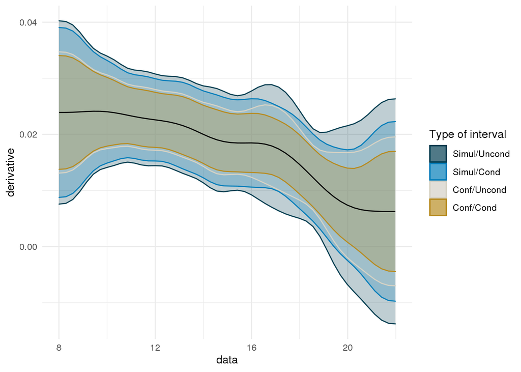

```r
ggplot(deriv1, aes(x = data, y = derivative)) +
  geom_ribbon(aes(ymin = lower, ymax = upper, color = 'Simul/Uncond', fill = 'Simul/Uncond'), alpha = .25) +
  geom_ribbon(data = deriv1aa, aes(ymin = lower, ymax = upper, color = 'Simul/Cond', fill = 'Simul/Cond'), alpha = .25) +
  geom_ribbon(data = deriv1a, aes(ymin = lower, ymax = upper, color = 'Conf/Uncond', fill = 'Conf/Uncond'), alpha = .25) +
  geom_ribbon(data = deriv1b, aes(ymin = lower, ymax = upper, color = 'Conf/Cond', fill = 'Conf/Cond'), alpha = .25) +
  scale_color_manual(breaks = c('Simul/Uncond', 'Simul/Cond', 'Conf/Uncond', 'Conf/Cond', 'Bayes'),
                     values = c(cpal[c(1:2, 4:5)], '#000000'),
                     name = 'Type of interval') +
  scale_fill_manual(breaks = c('Simul/Uncond', 'Simul/Cond', 'Conf/Uncond', 'Conf/Cond', 'Bayes'),
                     values = c(cpal[c(1:2, 4:5)], '#000000'),
                     name = 'Type of interval') +
  geom_line() +
  theme_minimal()
```

### Bayesian interval (w/ML)

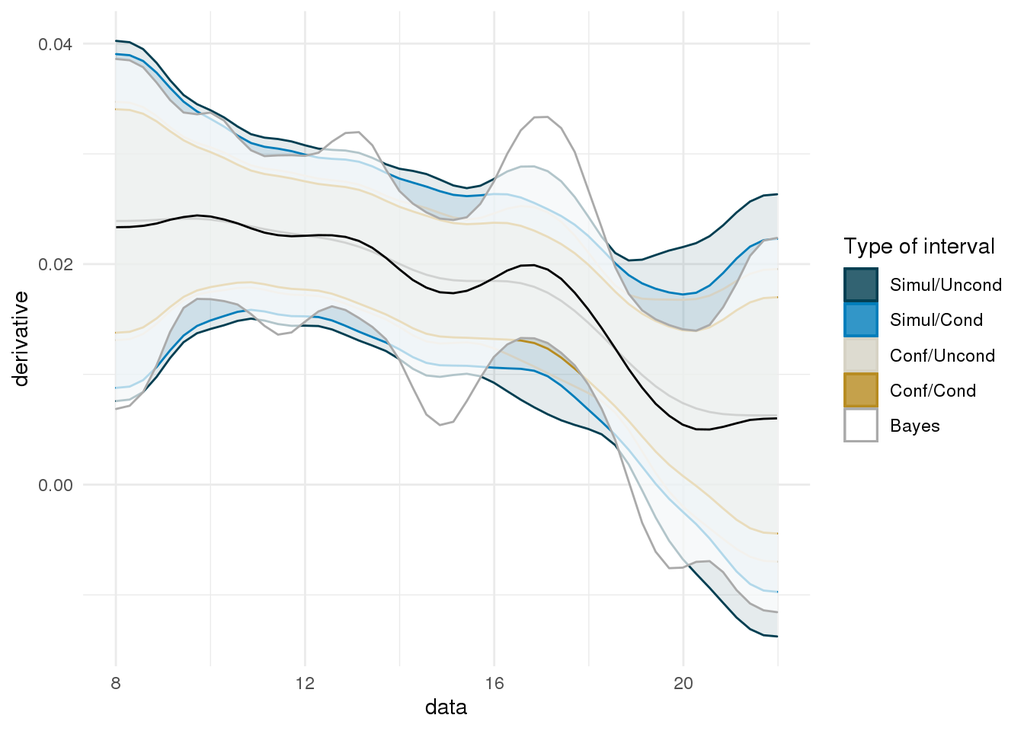

```r
ggplot(deriv1, aes(x = data, y = derivative)) +
  geom_ribbon(aes(ymin = lower, ymax = upper, color = 'Simul/Uncond', fill = 'Simul/Uncond'), alpha = .1) +
  geom_ribbon(data = deriv1aa, aes(ymin = lower, ymax = upper, color = 'Simul/Cond', fill = 'Simul/Cond'), alpha = .1) +
  geom_ribbon(data = deriv1a, aes(ymin = lower, ymax = upper, color = 'Conf/Uncond', fill = 'Conf/Uncond'), alpha = .1) +
  geom_ribbon(data = deriv1b, aes(ymin = lower, ymax = upper, color = 'Conf/Cond', fill = 'Conf/Cond'), alpha = .1) +
  geom_line(alpha = .5) +
  geom_ribbon(data = deriv1_post_summary, aes(x = Age, y = deriv1, ymin = lower, ymax = upper, color = 'Bayes', fill = 'Bayes'),
              alpha = .7) +
  geom_line(data = deriv1_post_summary, aes (x = Age, y = deriv1)) +
  scale_color_manual(breaks = c('Simul/Uncond', 'Simul/Cond', 'Conf/Uncond', 'Conf/Cond', 'Bayes'),
                     values = c(cpal[c(1:2, 4:5)], '#aaaaaa'),
                     name = 'Type of interval') +
  scale_fill_manual(breaks = c('Simul/Uncond', 'Simul/Cond', 'Conf/Uncond', 'Conf/Cond', 'Bayes'),
                    values = c(cpal[c(1:2, 4:5)], '#ffffff'),
                    name = 'Type of interval') +
  theme_minimal()
```

# Testing for regions of steepest slope

```r
fit_eval_ignore <- gratia:::confint.gam(fit, parm = 's(Age)', n = 100, unconditional = FALSE, type = 'confidence')
fit_eval <- gratia:::confint.gam(fit, parm = 's(Age)', n = 100, unconditional = TRUE, type = 'simultaneous', nsim = 10000)
```

In order to test where the GAM smooth derivative becomes different than the peak, we can explore a few different options:

1. Where does the the 83% CI for the maximum derivative no longer overlap the 83% CI for the derivative at other points?
2. Where is the maximum derivative different from the derivative at other points using pooled standard errors?
3. Using the posterior of the estimated smooth, compute the posterior of other quantities of interest, including
   1. The posterior for the derivative of the smooth
   2. The age where the median derivative is at its maximum
   3. The age where the derivative is maximized (across all posterior samples)
   4. The difference between the derivative, and the deriviative at the age computed in (2)

For the ML smooths, we will look at what happens when we take into account the two sources of uncertainty discussed above, and when we ignore them.

## Difference in 83% CIs

```r
deriv1_83 <- gratia::derivatives(fit, n = 100, level = .83, interval = 'simultaneous', unconditional = TRUE, n_sim = 10000)
i_max <- which(deriv1_83$derivative == max(deriv1_83$derivative))
max_lower <- deriv1_83$lower[i_max]

deriv1_83 <- deriv1_83 %>%
  mutate(compared_to_max = case_when(
    upper < max_lower ~ 'less_steep',
    TRUE ~ 'as_steep'
  ))
```

### Derivative

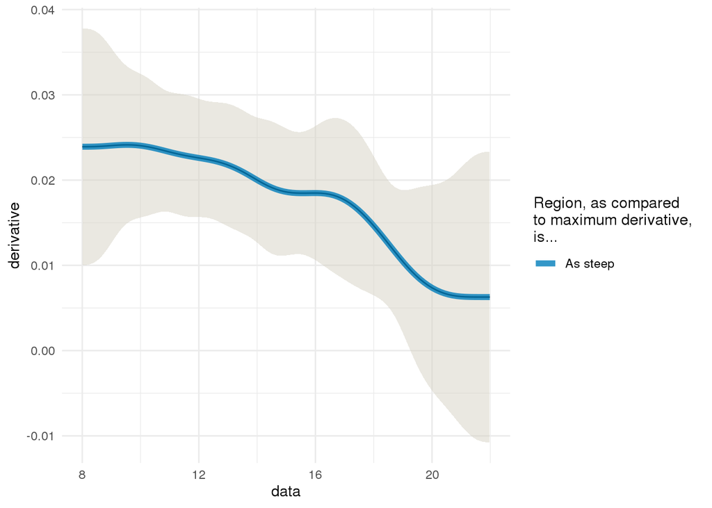

```r
ggplot(deriv1_83, aes(x = data, y = derivative)) +
  geom_ribbon(aes(ymin = lower, ymax = upper), alpha = .5, fill = cpal[4]) +
  geom_line() +
  geom_line(aes(color = compared_to_max, group = 1), size = 2, alpha = .8) +
  scale_color_manual(breaks = c('less_steep', 'as_steep'), values = cpal[c(5,2)],
                     labels = c('Less steep', 'As steep'),
                     name = 'Region, as compared \nto maximum derivative, \nis...') +
  theme_minimal()
```

### Smooth estimate

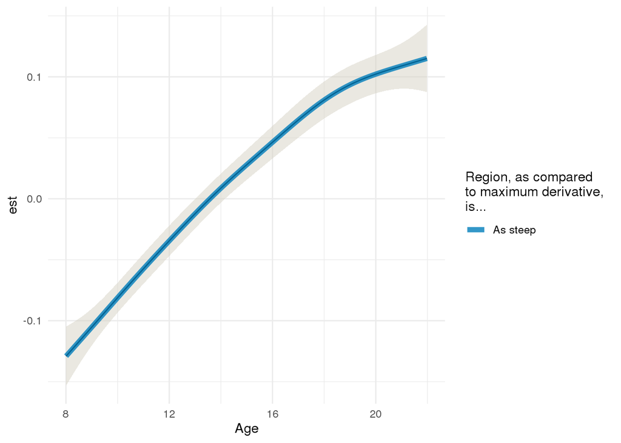

```r
ggplot(cbind(fit_eval, select(deriv1_83, compared_to_max)), aes(x = Age, y = est)) +
  geom_ribbon(aes(ymin = lower, ymax = upper), alpha = .5, fill = cpal[4]) +
  geom_line() +
  geom_line(aes(color = compared_to_max, group = 1), size = 2, alpha = .8) +
  scale_color_manual(breaks = c('less_steep', 'as_steep'), values = cpal[c(5,2)],
                     labels = c('Less steep', 'As steep'),
                     name = 'Region, as compared \nto maximum derivative, \nis...') +
  theme_minimal()
```

### Derivative (ignoring uncertainty)

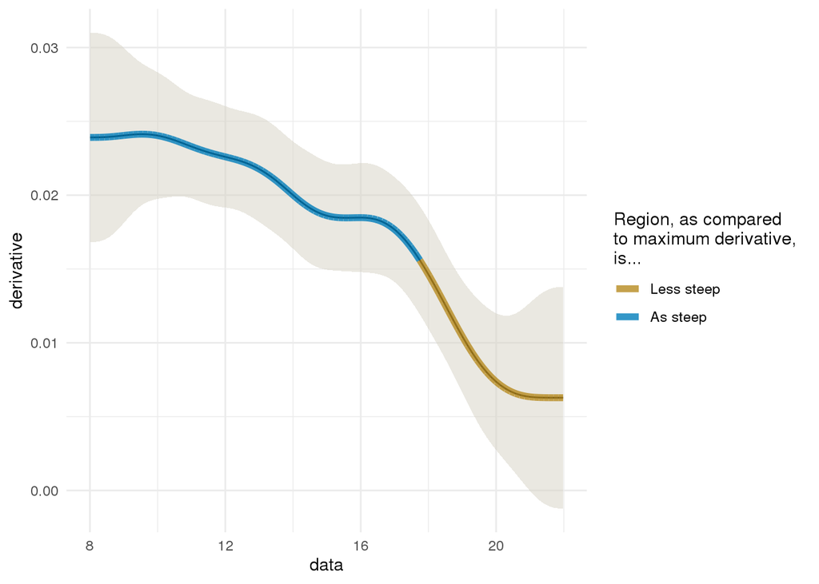

```r
deriv1b_83 <- gratia::derivatives(fit, n = 100, level = .83, interval = 'confidence', unconditional = FALSE)
i_max <- which(deriv1b_83$derivative == max(deriv1b_83$derivative))
max_lower <- deriv1b_83$lower[i_max]

deriv1b_83 <- deriv1b_83 %>%
  mutate(compared_to_max = case_when(
    upper < max_lower ~ 'less_steep',
    TRUE ~ 'as_steep'
  ))

ggplot(deriv1b_83, aes(x = data, y = derivative)) +
  geom_ribbon(aes(ymin = lower, ymax = upper), alpha = .5, fill = cpal[4]) +
  geom_line() +
  geom_line(aes(color = compared_to_max, group = 1), size = 2, alpha = .8) +
  scale_color_manual(breaks = c('less_steep', 'as_steep'), values = cpal[c(5,2)],
                     labels = c('Less steep', 'As steep'),
                     name = 'Region, as compared \nto maximum derivative, \nis...') +
  theme_minimal()
```

### Smooth estimate (ignoring uncertainty)

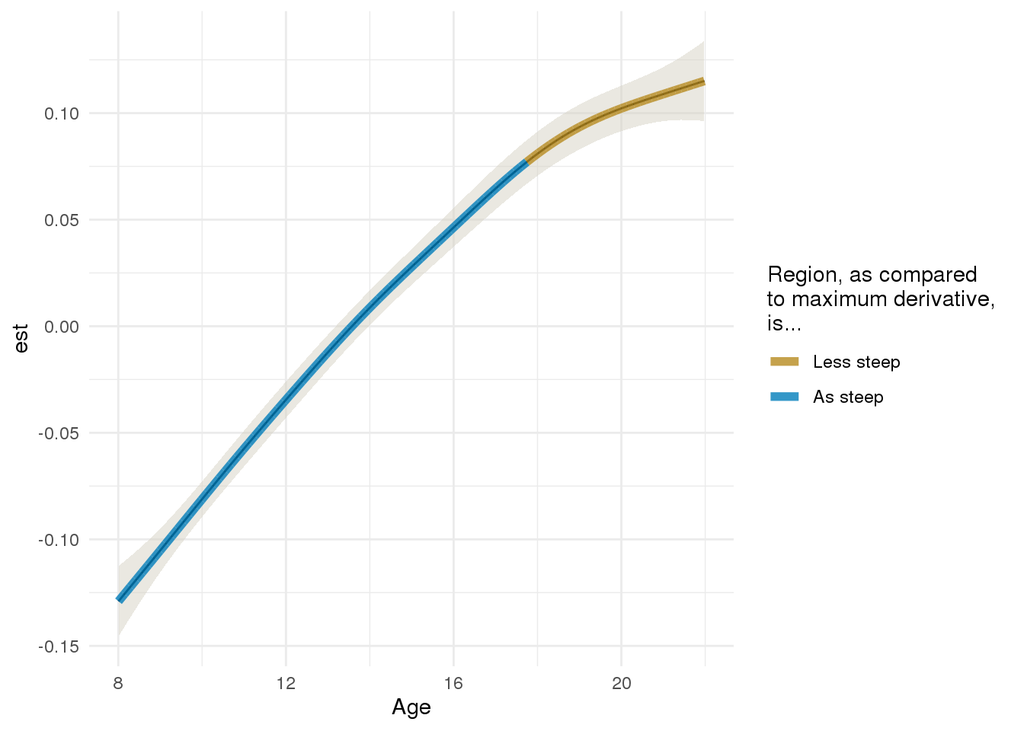

```r
ggplot(cbind(fit_eval_ignore, select(deriv1b_83, compared_to_max)), aes(x = Age, y = est)) +
  geom_ribbon(aes(ymin = lower, ymax = upper), alpha = .5, fill = cpal[4]) +
  geom_line() +
  geom_line(aes(color = compared_to_max, group = 1), size = 2, alpha = .8) +
  scale_color_manual(breaks = c('less_steep', 'as_steep'), values = cpal[c(5,2)],
                     labels = c('Less steep', 'As steep'),
                     name = 'Region, as compared \nto maximum derivative, \nis...') +
  theme_minimal()
```

## Difference in point estimates using pooled standard errors

```r
deriv1_se <- gratia::derivatives(fit, n = 100, level = .95, interval = 'simultaneous', unconditional = TRUE, n_sim = 10000)
i_max <- which(deriv1_se$derivative == max(deriv1_se$derivative))
max_est_se <- deriv1_se[i_max, c('derivative', 'se')]

deriv1_se <- deriv1_se %>%
  mutate(diff = derivative - max_est_se$derivative,
         se_diff = sqrt(se^2 + max_est_se$se^2),
         Z = diff/se_diff,
         compared_to_max = case_when(
           Z < -crit ~ 'less_steep',
           TRUE ~ 'as_steep'))
```

### Derivative

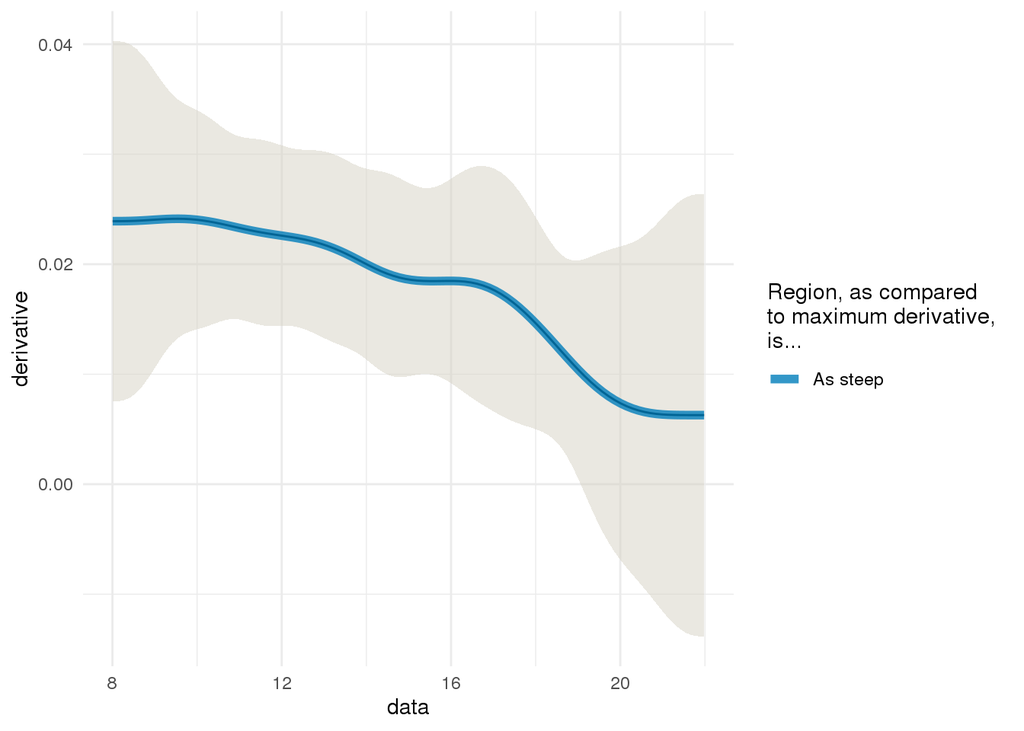

```r
ggplot(deriv1_se, aes(x = data, y = derivative)) +
  geom_ribbon(aes(ymin = lower, ymax = upper), alpha = .5, fill = cpal[4]) +
  geom_line() +
  geom_line(aes(color = compared_to_max, group = 1), size = 2, alpha = .8) +
  scale_color_manual(breaks = c('less_steep', 'as_steep'), values = cpal[c(5,2)],
                     labels = c('Less steep', 'As steep'),
                     name = 'Region, as compared \nto maximum derivative, \nis...') +
  theme_minimal()
```

### Difference in derivative (from maximum)

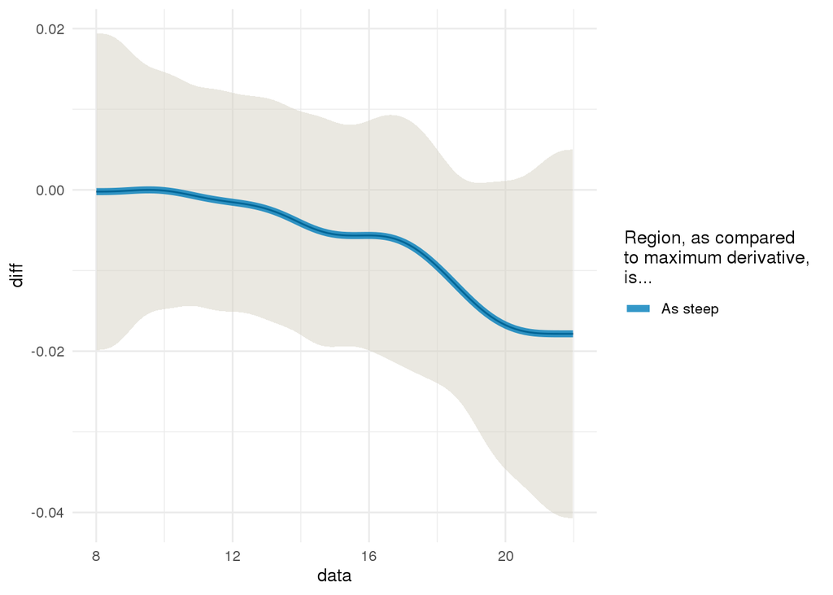

```r
ggplot(deriv1_se, aes(x = data, y = diff)) +
  geom_ribbon(aes(ymin = diff - crit*se_diff, ymax = diff + crit*se_diff), alpha = .5, fill = cpal[4]) +
  geom_line() +
  geom_line(aes(color = compared_to_max, group = 1), size = 2, alpha = .8) +
  scale_color_manual(breaks = c('less_steep', 'as_steep'), values = cpal[c(5,2)],
                     labels = c('Less steep', 'As steep'),
                     name = 'Region, as compared \nto maximum derivative, \nis...') +
  theme_minimal()
```

### Smooth estimate

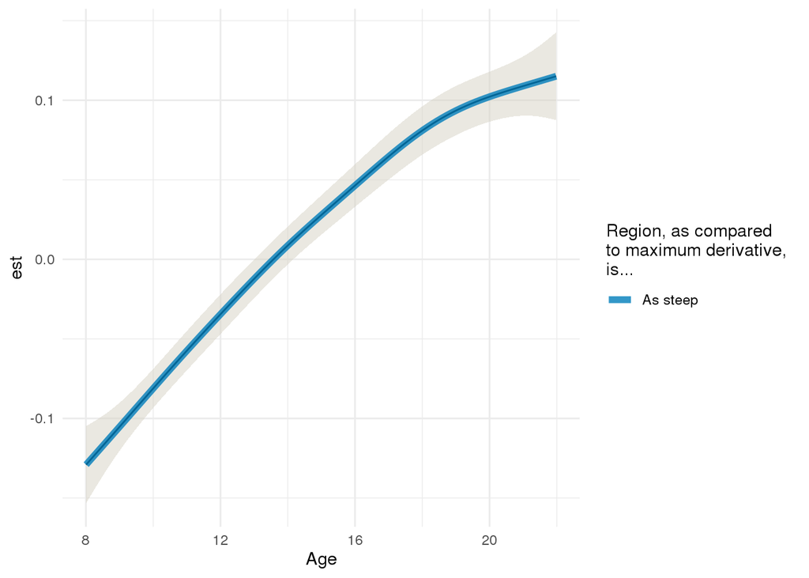

```r
ggplot(cbind(fit_eval, select(deriv1_se, compared_to_max)), aes(x = Age, y = est)) +
  geom_ribbon(aes(ymin = lower, ymax = upper), alpha = .5, fill = cpal[4]) +
  geom_line() +
  geom_line(aes(color = compared_to_max, group = 1), size = 2, alpha = .8) +
  scale_color_manual(breaks = c('less_steep', 'as_steep'), values = cpal[c(5,2)],
                     labels = c('Less steep', 'As steep'),
                     name = 'Region, as compared \nto maximum derivative, \nis...') +
  theme_minimal()
```

### Derivative (ignoring uncertainty)

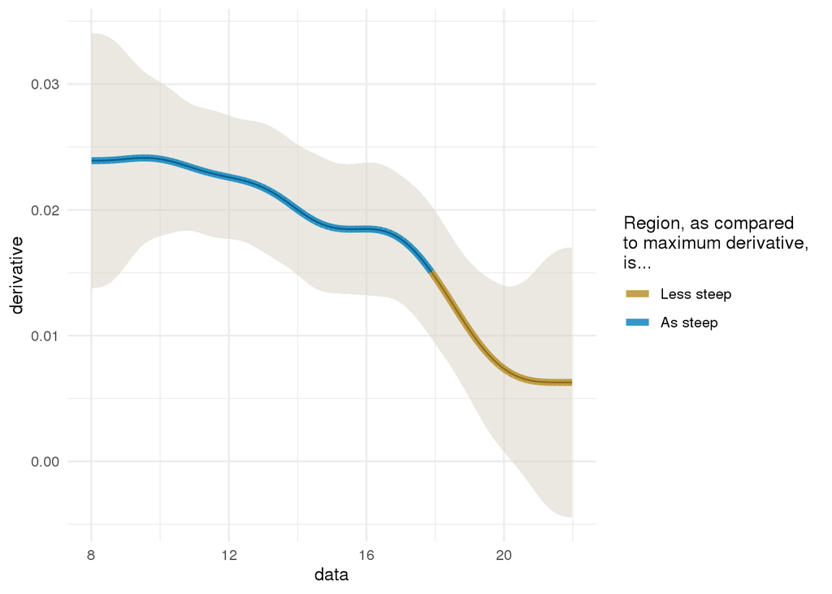

```r
deriv1b_se <- gratia::derivatives(fit, n = 100, level = .95, interval = 'confidence', unconditional = FALSE)
i_max <- which(deriv1b_se$derivative == max(deriv1b_se$derivative))
max_est_se <- deriv1b_se[i_max, c('derivative', 'se')]

deriv1b_se <- deriv1b_se %>%
  mutate(diff = derivative - max_est_se$derivative,
         se_diff = sqrt(se^2 + max_est_se$se^2),
         Z = diff/se_diff,
         compared_to_max = case_when(
           Z < -crit ~ 'less_steep',
           TRUE ~ 'as_steep'))

ggplot(deriv1b_se, aes(x = data, y = derivative)) +
  geom_ribbon(aes(ymin = lower, ymax = upper), alpha = .5, fill = cpal[4]) +
  geom_line() +
  geom_line(aes(color = compared_to_max, group = 1), size = 2, alpha = .8) +
  scale_color_manual(breaks = c('less_steep', 'as_steep'), values = cpal[c(5,2)],
                     labels = c('Less steep', 'As steep'),
                     name = 'Region, as compared \nto maximum derivative, \nis...') +
  theme_minimal()
```

### Difference in derivative (from maximum, ignoring uncertainty)

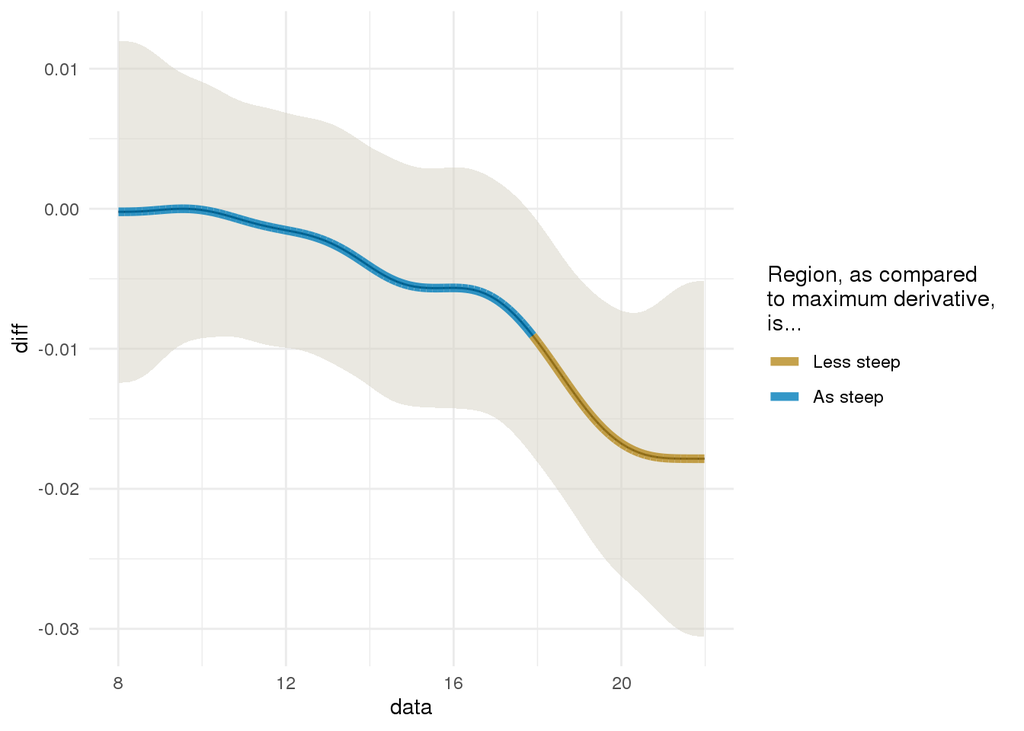

```r
ggplot(deriv1b_se, aes(x = data, y = diff)) +
  geom_ribbon(aes(ymin = diff - crit*se_diff, ymax = diff + crit*se_diff), alpha = .5, fill = cpal[4]) +
  geom_line() +
  geom_line(aes(color = compared_to_max, group = 1), size = 2, alpha = .8) +
  scale_color_manual(breaks = c('less_steep', 'as_steep'), values = cpal[c(5,2)],
                     labels = c('Less steep', 'As steep'),
                     name = 'Region, as compared \nto maximum derivative, \nis...') +
  theme_minimal()
```

### Smooth estimate (ignoring uncertainty)

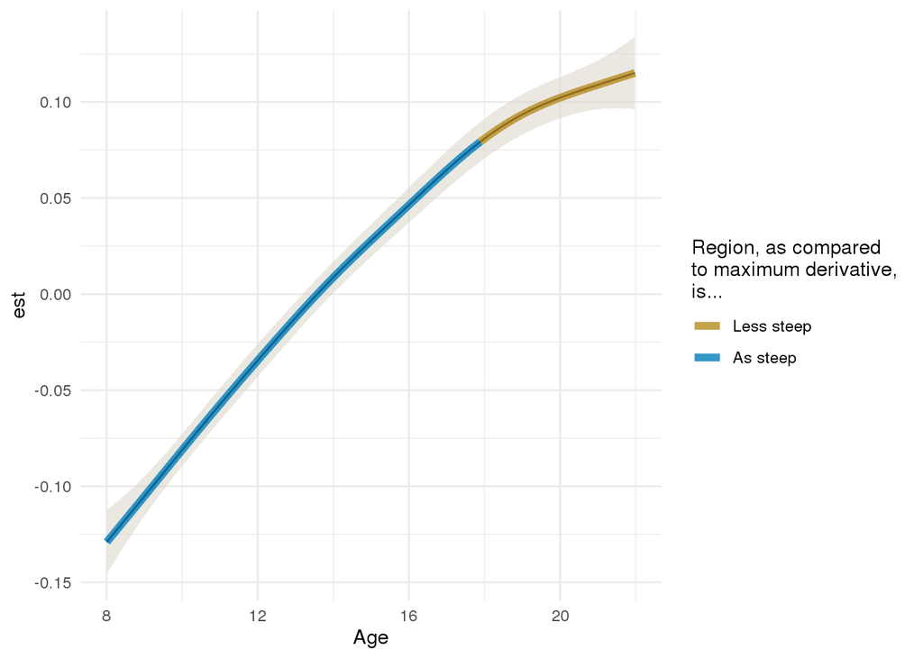

```r
ggplot(cbind(fit_eval_ignore, select(deriv1b_se, compared_to_max)), aes(x = Age, y = est)) +
  geom_ribbon(aes(ymin = lower, ymax = upper), alpha = .5, fill = cpal[4]) +
  geom_line() +
  geom_line(aes(color = compared_to_max, group = 1), size = 2, alpha = .8) +
  scale_color_manual(breaks = c('less_steep', 'as_steep'), values = cpal[c(5,2)],
                     labels = c('Less steep', 'As steep'),
                     name = 'Region, as compared \nto maximum derivative, \nis...') +
  theme_minimal()
```

## Use posterior of Bayesian smooth

```r
# This may be helpful: https://github.com/paul-buerkner/brms/issues/738
```

### Derivative

Age where the median posterior derivative is at its max is marked.

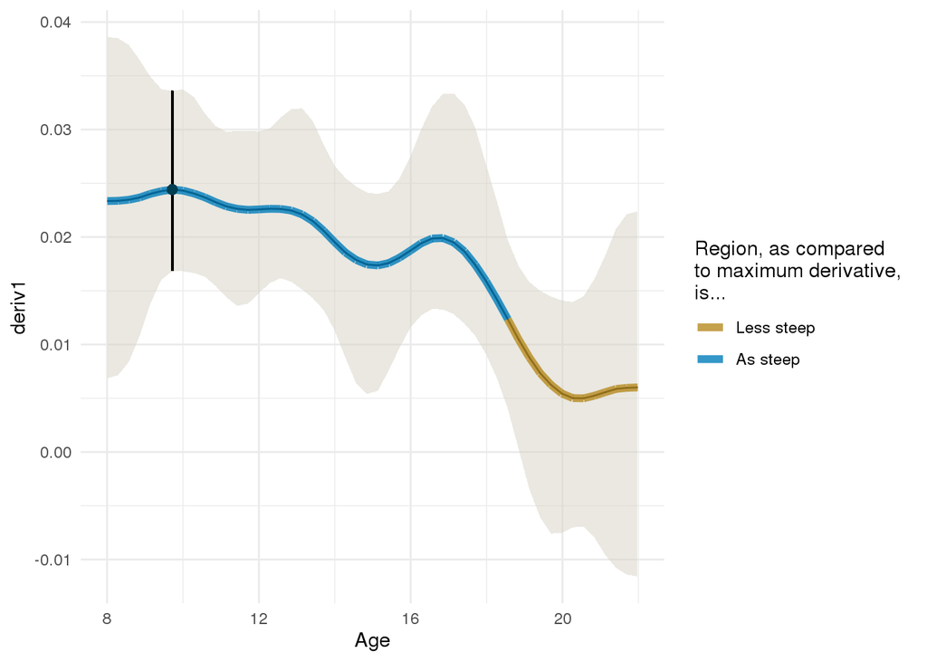

```r
ggplot(deriv1_post_summary, aes(x = Age, y = deriv1)) +
  geom_ribbon(aes(ymin = lower, ymax = upper), alpha = .5, fill = cpal[4]) +
  geom_segment(x = age_at_max_med_deriv,
               xend = age_at_max_med_deriv,
               y = deriv1_post_summary[Age == age_at_max_med_deriv, lower],
               yend = deriv1_post_summary[Age == age_at_max_med_deriv, upper]) +
  geom_line() +
  geom_line(aes(color = compared_to_max, group = 1), size = 2, alpha = .8) +
  geom_point(x = age_at_max_med_deriv, y = deriv1_post_summary[Age == age_at_max_med_deriv, deriv1], color = cpal[1], size = 2) +
  scale_color_manual(breaks = c('less_steep', 'as_steep'), values = cpal[c(5,2)],
                     labels = c('Less steep', 'As steep'),
                     name = 'Region, as compared \nto maximum derivative, \nis...') +
  theme_minimal()
```

### Age at maximum derivative

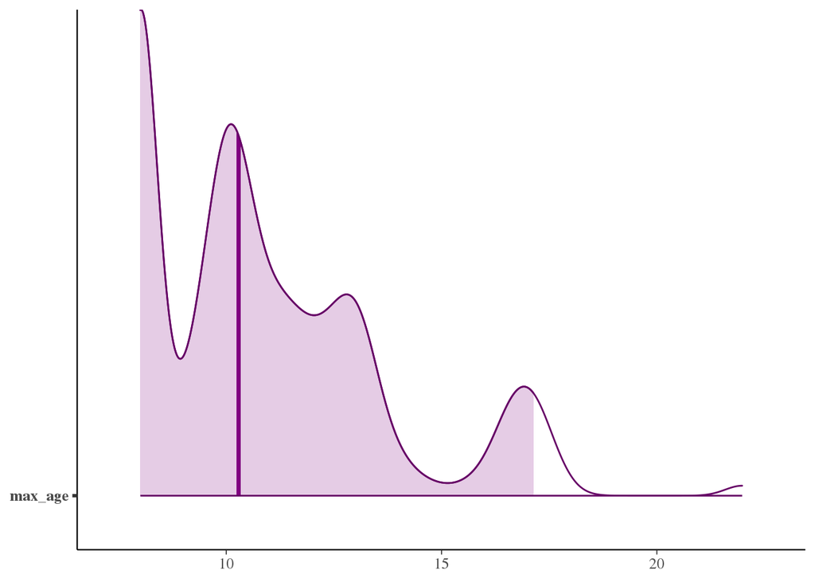

```r
bayesplot::color_scheme_set('purple')
bayesplot::mcmc_areas(data.frame(max_age = deriv1_age_at_max_post$max_age, Chain = rep(1:4, each = 2500)),
                      prob = 0.95,
                      prob_outer = 0.99)
```

### Difference from derivative at steepest age

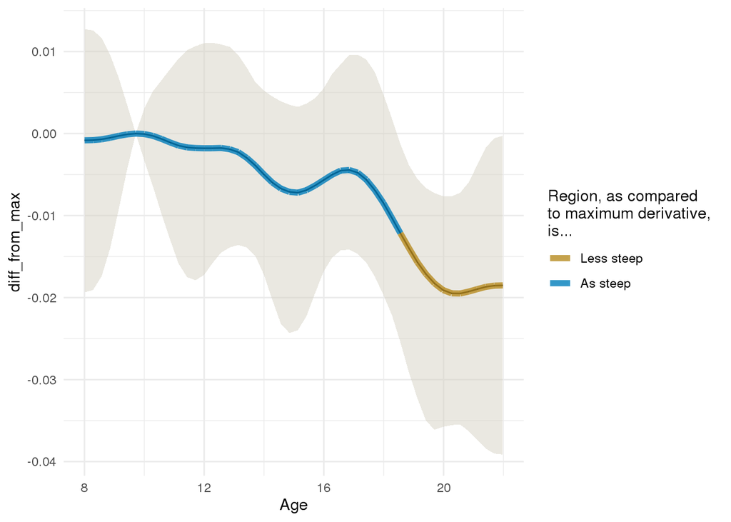

```r
ggplot(deriv1_diff_from_max_post_summary, aes(x = Age, y = diff_from_max)) +
  geom_ribbon(aes(ymin = lower, ymax = upper), alpha = .5, fill = cpal[4]) +
  geom_line() +
  geom_line(aes(color = compared_to_max, group = 1), size = 2, alpha = .8) +
  scale_color_manual(breaks = c('less_steep', 'as_steep'), values = cpal[c(5,2)],
                     labels = c('Less steep', 'As steep'),
                     name = 'Region, as compared \nto maximum derivative, \nis...') +
  theme_minimal()
```

### Smooth estimate

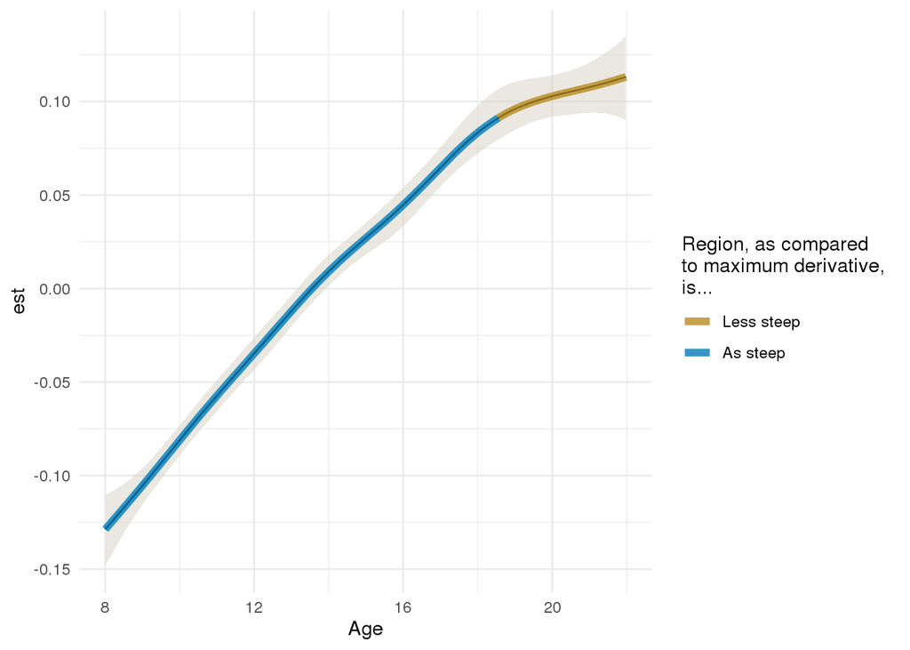

```r
ggplot(smooth_post_summary[deriv1_diff_from_max_post_summary[, .(Age, compared_to_max)], on = 'Age'],
       aes(x = Age, y = est)) +
  geom_ribbon(aes(ymin = lower, ymax = upper), alpha = .5, fill = cpal[4]) +
  geom_line() +
  geom_line(aes(color = compared_to_max, group = 1), size = 2, alpha = .8) +
  scale_color_manual(breaks = c('less_steep', 'as_steep'), values = cpal[c(5,2)],
                     labels = c('Less steep', 'As steep'),
                     name = 'Region, as compared \nto maximum derivative, \nis...') +
  theme_minimal()
```